# Taller 3 — Economías de Aglomeración

Author

Juan Manuel Bayona Pacheco

Published

2026-03-13

## Taller 3 de Econometría Espacial

# 1. Mapa de densidad y distribución de empresas del sector insumos intermedios de construcción

Realice el mapa de densidad y distribución de puntos de las empresas del sector seleccionado. Interprete los resultados en términos de la localización de las mayores densidades.Indague sobre el contexto de esta industria en Cali para dar una explicación con sentido económico.

### a) Distribución espacial

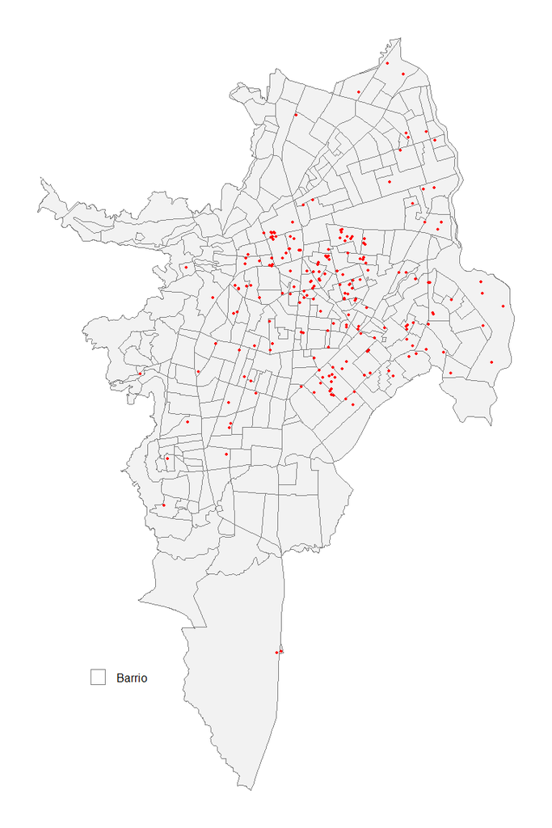

```r
# ─── 6. Mapa de distribución de puntos del sector ─────────────────────────────
ggplot() +
  geom_sf(data = barriosCali,
          aes(fill = "Barrio"),
          color = "grey50", linewidth = 0.25) +
  scale_fill_manual(values = c("Barrio" = "grey95"),
                    name   = "",
                    guide  = guide_legend(
                      order        = 1,
                      keywidth     = unit(0.3, "cm"),
                      keyheight    = unit(0.3, "cm"),
                      override.aes = list(alpha = 0.1),
                      label.theme  = element_text(size = 6))) +
  geom_sf(data = points, color = "red", size = 0.30, alpha = 2) +
  theme_void() +
  theme(legend.position  = c(0.2, 0.2),
        legend.title     = element_text(size = 10),
        legend.spacing.y = unit(-0.3, "cm"))
```

### a) Funcion de densidad espacial

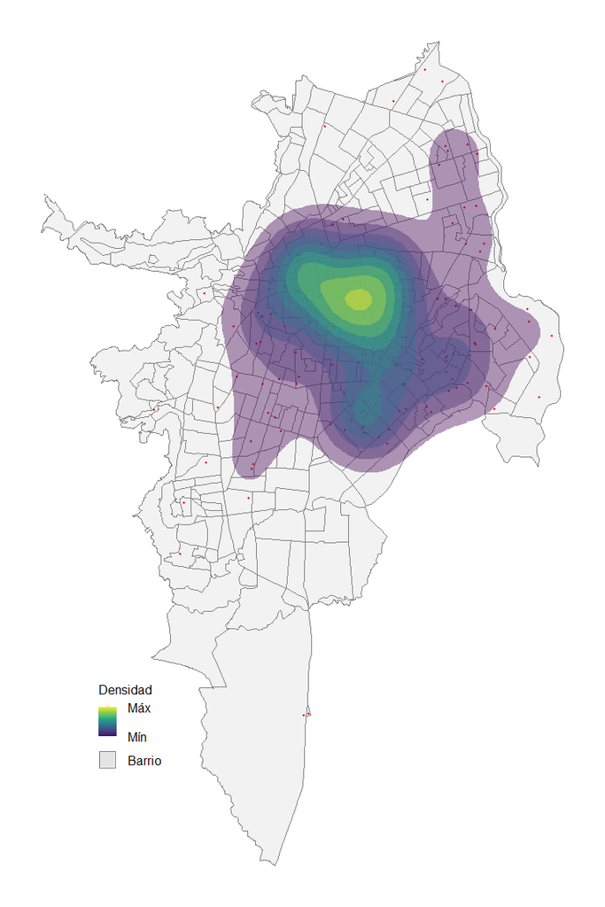

```r
# ─── 7. Mapa de densidad kernel bidimensional del sector ──────────────────────
ggplot() +
  geom_sf(data = barriosCali,
          aes(fill = "Barrio"),
          color = "grey50", linewidth = 0.25) +
  scale_fill_manual(values = c("Barrio" = "grey95"),
                    name   = "",
                    guide  = guide_legend(
                      order        = 1,
                      keywidth     = unit(0.3, "cm"),
                      keyheight    = unit(0.3, "cm"),
                      override.aes = list(alpha = 0.1),
                      label.theme  = element_text(size = 6))) +
  geom_sf(data = points, color = "red", size = 0.20, alpha = 1) +
  new_scale_fill() +
  stat_density_2d(data = data,
                  aes(x = x, y = y, fill = after_stat(level)),
                  geom       = "polygon",   # Áreas rellenas por nivel de densidad
                  alpha      = 0.4,
                  color      = NA,          # Sin borde entre niveles
                  show.legend = TRUE) +
  scale_fill_viridis_c(option = "viridis",
                       breaks = function(x) range(x),
                       labels = c("Mín", "Máx"),
                       name   = "Densidad",
                       guide  = guide_colorbar(
                         order        = 1,
                         barwidth     = unit(0.3, "cm"),
                         barheight    = unit(0.5, "cm"),
                         title.theme  = element_text(size = 6),
                         label.theme  = element_text(size = 6))) +
  theme_void() +
  theme(legend.position  = c(0.2, 0.2),
        legend.title     = element_text(size = 10),
        legend.spacing.y = unit(-0.3, "cm"))
```

Los mapas de distribución espacial y densidad sugieren una concentración de empresas dedicadas a la fabricación de partes y piezas de carpintería para edificios y construcción en la zona norte-central de Cali. Esta aglomeración puede explicarse por la presencia de economías de aglomeración asociadas al sector de la construcción. Históricamente, el centro de la ciudad ha concentrado proveedores de insumos, ferreterías y comercios mayoristas de materiales de construcción, lo que facilita los encadenamientos productivos y reduce los costos logísticos de las empresas. Asimismo, al tratarse de insumos intermedios para este sector productivo, la localización central permite un acceso más directo a la demanda proveniente de proyectos de construcción y remodelación, generando beneficios de información asociados a la concentración de trabajadores especializados en un espacio próximo.

# 2. Índices de concentración espacial

Calcule los siguientes índices de concentración e interprételos con sentido económico, teniendo en cuenta el contexto de la ciudad.

### a) Índice de Herfindahl–Hirschman (IHH)

El **Índice de Herfindahl-Hirschman (IHH)** mide el grado de concentración de una actividad económica en un conjunto de unidades geográficas(Herfindahl, 1950; Hirschman, 1945). En este contexto, permite evaluar qué tan concentradas están las empresas del sector en los distintos barrios de Cali. Matemáticamente se define como:

$$HHI = \sum_{i=1}^{N} s_i^2$$

donde $s_i$ es la participación en empleo del barrio $i$ en el total de empleo del sector, y $N$ es el número de barrios con al menos una empresa del sector.

```
Numero de puestos de trabajo en el sector de insumos intermedios en construcción: 585
```

```
Numero de puestos de trabajo en la economia caleña: 40679
```

```
Participación del sector en terminos de empleo: 1.44%
```

```
# A tibble: 5 × 3
  barrio                empleo  share
  <chr>                  <int>  <dbl>
1 SAN NICOLAS               62 0.106
2 SAN PASCUAL               43 0.0735
3 UNION DE VDA. POPULAR     34 0.0581
4 EL TRONCAL                33 0.0564
5 EL RODEO                  30 0.0513
```

```
HHI por numero de empleo en los barrios de Cali: 0.0337
```

El IHH sugiere que la actividad se encuentra distribuida entre varios barrios y no concentrada en uno o pocos de ellos. Este resultado contrasta con la concentración visual observada en el mapa de densidad, lo que puede atribuirse a dos sesgos estructurales del estimador: primero, el **sesgo de tamaño y aglomeración**, donde la concentración de toda la economía en un barrio puede inflar la participación del sector sin que ello refleje especialización sectorial propia, o viceversa, la baja cantidad de empleo relativo al tamaño de la empleabilidad del sector, podria reflejar no especialización cuando realmente si lo hay en barrios especificos; segundo, el **sesgo de unidad espacial** (*MAUP*), dado que el IHH trata cada barrio como una unidad independiente sin considerar la dependencia espacial entre barrios contiguos. Los índices siguientes buscan corregir cada uno de estos sesgos progresivamente.

### b) Índice de Ellison y Glaeser (1997)

El **Índice de Ellison y Glaeser (EG)** mide el grado de aglomeración espacial de una industria corrigiendo dos sesgos del IHH: (1) la concentración del empleo general de la actividad económica en la ciudad, y (2) la participacion relativa de las empresas al empleo dentro del sector (Ellison y Glaeser, 1997). El índice se define como:

$$\hat{\gamma}_{EG} = \frac{G_{EG}}{(1-\sum_{i=1}^{N} x_i^2)(1-H)} - \frac{H}{1-H}$$

donde:

$$G_{EG} = \sum_{i=1}^{N}(s_i - x_i)^2 \qquad H = \sum_{j=1}^{J} z_j^2$$

- $s_i$ = participación del empleo del sector en el barrio $i$
- $x_i$ = participación del empleo de todas las empresas de la ciudad en el barrio $i$
- $H$ = índice de Herfindahl del tamaño de las plantas dentro del sector en el sentido del empleo
- $J$ = número total de empresas del sector
- $z_j$ = participación del empleo de la empresa $j$ en el empleo total del sector

$$\hat{\gamma}_{EG} \propto \frac{G_{EG}}{1-\sum_{i=1}^{N} x_i^2}$$

los autores proponen los siguientes umbrales de interpretación.

| $\hat{\gamma}_{EG}$ | Interpretación |
| --- | --- |
| $\hat{\gamma}_{EG} < 0.02$ | Poca o ninguna aglomeración |
| $0.02 \leq \hat{\gamma}_{EG} \leq 0.05$ | Aglomeración moderada |
| $\hat{\gamma}_{EG} > 0.05$ | Alta aglomeración |

```
ratio entre empleo del sector y el empleo general en barrios con al menos 1 empresa del sector construcción: 3.11%
```

```
gamma_EG: 0.0696
```

```
z-stat:   1.9063
```

```
p-value:  0.0566
```

El índice EG corrige el sesgo de concentración total de la economía presente en el IHH. En Cali, cuando condicionamos a los barrios donde existe al menos una empresa del sector, la participación del empleo se duplica, pasando de $1.4\%$ a $3.11\%$, esto indica, que el sector agrega un puesto de trabajo adicional en los barrios donde se ubica, sugiriendo alta aglomeración relativa a la empleabilidad general de la economía. Precisamente, el estadistico $\hat{\gamma}_{EG} = 0.06$ muestra signos de alta aglomeración según el umbral que proponen los autores, mayores a la economía, con p-value de 0.0566, que indica la baja probabilidad de encontrar casos extremos de aglomeración más alla del observado por el sector, la hipotesis nula al $10\%$ es rechazada, pero no puede ser rechazada para los niveles de significanciaa del $5\%$ al $1\%$, aunque hay una leve inclinación de aglomeración en barrios especificos condicional a la economía misma, la evidencia obtenida no es concluyente.

### c) Índice de Maurel y Sédillot (1999)

El índice de Maurel y Sédillot (MS) es una extensión del EG que refina la definición de probabilidad de co-localización (Maurel y Sédillot, 1999). Mientras EG evalúa la probabilidad de que dos trabajadores del sector se ubiquen en el mismo barrio respecto a dos trabajadores de cualquier sector, MS condiciona exclusivamente sobre pares de trabajadores que pertenecen a **empresas distintas** dentro del sector, eliminando la información de co-localización intra-empresa que EG incluye mecánicamente. Formalmente:

$$\hat{\gamma}_{MS} = \frac{G_{MS}}{(1-\sum_{i=1}^{N} x_i^2)(1-H)} - \frac{H}{1-H}$$

donde:

$$G_{MS} = \sum_i (s_i^2 - x_i^2)$$

La hipótesis nula de ambos estimadores es la misma: la distribución intrasectorial es indistinguible de la distribución multisectorial a lo largo de Cali. La diferencia es como definen esas distribuciónes.

```
gamma_MS: -0.1223
```

$\hat{\gamma}_{MS} = -0.1223$ ofrece una visión más conservadora de la aglomeración sectorial. El signo negativo es explicado por una menor aglomeración del sector referente a la aglomeración de la economía, esto puede ser explicado por Barrios tradicionalmente comerciales como San Nicolas que abarcan un gran numero de empleos de la economía caleña en distintos sectores, disminuyendo la probabilidad relativa de co-localizacion de dos trabajadores en el sector, en consecuencia, el indice pronostica una subrepresentación del sector en promedio sobre todos los barrios analizados.

La diferencia— frente al valor positivo de $\hat{\gamma}_{EG}$ — se explica por la diferente definición de $G$: MMS descarta el término cruzado $2\sum_i s_i x_i$ que EG incluye, de modo que cuando el sector está subrepresentado en los barrios de mayor peso económico, $G_{MS}$ resulta menor que $G_{EG}$, generando una estimación de $\gamma$ más baja e incluso negativa. En conjunto, ambos estimadores confirman la distintas hipotesis: las decisiones de co-localización de las empresas de insumos intermedios para construcción en Cali obedecen cierto proceso de clusterización en barrios específicos, sin embargo, la distribucion de probabilidad de co-localización en empresas distintas del sector parece seguir la distribución de trabajar en cualquier empresa sectorialmente distinta.

### d) Cociente de Localización (LQ) e Índice de Aislamiento (IQ)

El **Cociente de Localización** (LQ) mide cuántas empleo del sector existen por empleo de la economía general en el barrio $i$, formalmente:

$$LQ_i = \frac{s_i}{x_i} = \frac{e_{si}/E_s}{e_i/E}$$

donde $e_{si}$ es el número de empleos del sector en el barrio $i$, $E_s$ es el total de empleos en el sector, $e_i$ el total de empleos multisectoriales en el barrio $i$, y $E$ el total de empleos en la economía. Un $LQ_i > 1$ indica especialización relativa del barrio en el sector; $LQ_i < 1$ señala subrepresentación.

El **Índice de Aislamiento** (IQ) pondera el LQ por la empleabilidad del sector en el barrio i $s_i$, produciendo el LQ promedio que enfrenta un trabajador tipico del sector dado su barrio de localización:

$$IQ = \sum_i s_i \cdot LQ_i = \sum_i \frac{s_i^2}{x_i}$$

Un $IQ > 1$ indica que, en promedio, el empleo del sector se localizan en barrios con mayor empleabilidad sectorial que la media de Cali.

```
# A tibble: 10 × 6
   barrio                       empleo empleo_total_barrio      si      xi    LQ
   <chr>                         <int>               <int>   <dbl>   <dbl> <dbl>
 1 EL MORTINAL                       2                   2 0.00342 1.06e-4 32.1
 2 RODRIGO LARA BONILLA             11                  23 0.0188  1.22e-3 15.4
 3 JOSE M. CORDOBA                   8                  19 0.0137  1.01e-3 13.5
 4 SECTOR LOS MANGOS (CANAV.NO…      2                   5 0.00342 2.66e-4 12.9
 5 EL RODEO                         30                  89 0.0513  4.73e-3 10.8
 6 BELLO HORIZONTE                   4                  12 0.00684 6.38e-4 10.7
 7 SAN MARINO                        3                  10 0.00513 5.32e-4  9.64
 8 PETECUY III                       6                  21 0.0103  1.12e-3  9.18
 9 EL PRADO                          2                   8 0.00342 4.25e-4  8.04
10 UNION DE VDA. POPULAR            34                 148 0.0581  7.87e-3  7.38
```

```
IQ (Índice de Aislamiento): 3.6852
```

```
# A tibble: 13 × 6
   barrio                 empleo empleo_total_barrio     si      xi     LQ
   <chr>                   <int>               <int>  <dbl>   <dbl>  <dbl>
 1 SAN NICOLAS                62                6297 0.106  0.335    0.316
 2 SAN PASCUAL                43                 272 0.0735 0.0145   5.08
 3 UNION DE VDA. POPULAR      34                 148 0.0581 0.00787  7.38
 4 EL TRONCAL                 33                 828 0.0564 0.0440   1.28
 5 EL RODEO                   30                  89 0.0513 0.00473 10.8
 6 LA FLORESTA                17                 220 0.0291 0.0117   2.48
 7 BARRIO OBRERO              15                 827 0.0256 0.0440   0.583
 8 NUEVA FLORESTA DEL ICT     12                 210 0.0205 0.0112   1.84
 9 ANTONIO NARI�O             11                  74 0.0188 0.00394  4.78
10 CHAPINERO                  11                 129 0.0188 0.00686  2.74
11 RODRIGO LARA BONILLA       11                  23 0.0188 0.00122 15.4
12 SANTANDER                  11                1051 0.0188 0.0559   0.336
13 SIN DEFINIR                11                 358 0.0188 0.0190   0.988
```

Para corregir esta limitación, el $IQ = \sum_i s_i^2/x_i$ pondera el $LQ$ por la participación del sector $s_i$, produciendo las odds-probabilities de co-localizacion de dos trabajadores en el sector respecto a co-localizacion de dos trabajadores en cualquier sector— es decir, mide las probabilidades relativas en promedio para todo cali que enfrentan dos individuos para posicionarse en un mismo barrio en un mismo sector. Un valor $IQ = 3.68$ indica que el empleo sector tienden a localizarse en barrios donde la densidad sectorial es el triple del promedio de la ciudad. Los barrios analíticamente relevantes — aquellos que combinan $s_i$ suficiente con especialización genuina — son tres. **El rodeo** presenta la mayor especialización relativa con soporte muestral razonable:el $33\%$ de los empleos proviene del sector analizado($e_s = 30$,$e = 89$) ($LQ = 10.83$), lo que indica que encontrar trabajo en el sector de construcción en el rodeo es aproximadamente 10 veces más probable que el empleo en cualquier otro sector economico, coherente con un proceso de especialización especifico en ese barrio.En la misma linea, **San Pascual** concentra alrebedor de $43$ puestos de empleos representando cerca del $7.35\%$ de los empleos del sector. Posee unas odds de $LQ = 5.08$, sugiriendo que las probabilidades de conseguir empleo en el sector son 5 veces mayor respecto a los distintos sectores, mostrando robustez por especialización genuina respaldada por masa muestral. En el sentido opuesto, **San Nicolás**, siendo el corredor comercial más importante de Cali al abarcar el $33.49\%$ de toda la actividad empresarial en los barrios seleccionados, presenta un $LQ = 0.3164$, resultado consistente con una economía suficientemente diversificada donde ningún sector logra sobre-representarse — su peso en el $IQ$ es alto por $s_i$, pero su $LQ < 1$ lo excluye como polo de especialización constructora.

# 3. Mapa del coeficiente de localización (LQ)

Construya el mapa del coeficiente de localización (Location Quotient, LQ) para el sector analizado e interprete los resultados en términos de especialización productiva de los barrios de la ciudad.

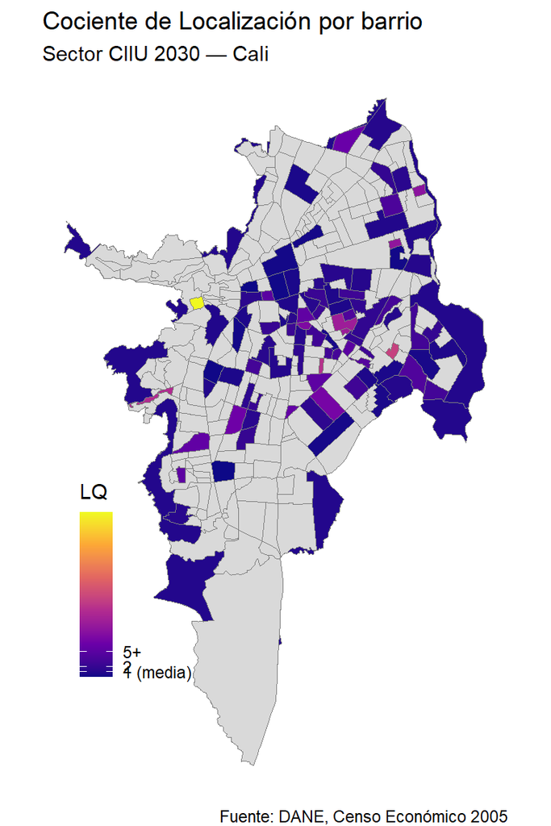

Los índices anteriores comparten una limitación común: operan sobre particiones discretas del espacio en barrios, lo que introduce dependencia de los resultados respecto a cómo se definen las fronteras geográficas (*MAUP*). Las funciones $\hat{K}_d$ y $M$ resuelven este problema estimando aglomeración sobre el espacio continuo, evaluando directamente las distancias entre establecimientos.

# 4. funciones de densidad de distancia $\hat{K}_d$ de Duranton y Overman (2005) y $M$ de Marcon y Puech (2010).

La función $\hat{K}_d$ estima la densidad de distancias bilaterales entre establecimientos del sector, evaluando si la distribución empírica de esas distancias difiere significativamente de una distribución de referencia aleatoria (Duranton y Overman, 2005). Formalmente:

$$\hat{K}_d(d) = \frac{1}{n(n-1)} \sum_{i=1}^{n} \sum_{j \neq i} \frac{1}{h}\phi\left(\frac{d - d_{ij}}{h}\right)$$

donde $d_{ij}$ es la distancia euclidiana entre los establecimientos $i$ y $j$, $\phi(\cdot)$ es el kernel gaussiano estándar con ancho de banda $h$, y $n$ es el número total de establecimientos del sector. El contrafactual se construye mediante remuestreo aleatorio de las localizaciones observadas en la economía general, generando bandas de confianza al $5\%$ por simulación de Monte Carlo. Se concluye:

- **Aglomeración** a distancia $d$ si $\hat{K}_d(d) >$ banda superior
- **Dispersión** a distancia $d$ si $\hat{K}_d(d) <$ banda inferior
- **Aleatoriedad** si $\hat{K}_d(d)$ se encuentra dentro de las bandas

```
Ancho de banda h (Silverman): 268.3 metros
```

```
Radio efectivo de influencia (3h): 804.8 metros
```

```
Moda sector: 2816.4 metros
```

```
Moda economía general: 3492.3 metros
```

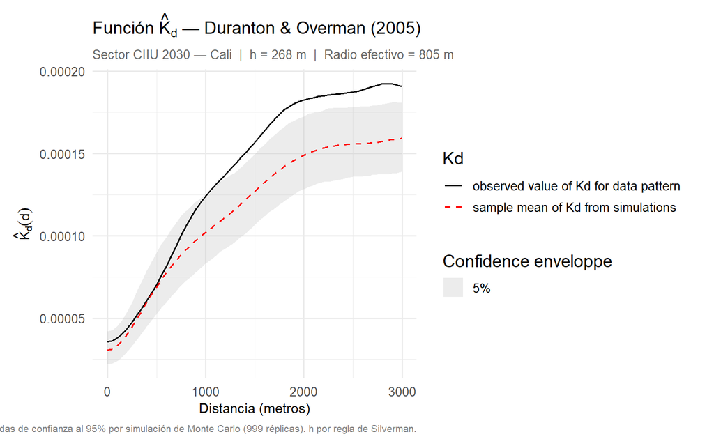

La función $\hat{K}_d$ ofrece tres lecturas complementarias sobre la estructura espacial del sector. Primero, las distancias entre pares de empresas del sector tienen una moda de $2.816$ metros, indicando que la mayor densidad probabilística de encontrar dos empresas del sector se da a esa escala — equivalente a una distancia de caminata urbana extendida. Que el sector no exhiba una moda a distancias muy cortas sugiere que no existe un incentivo predominante de co-localización inmediata, lo que es consistente con la naturaleza del bien que comercia: insumos intermedios cuya demanda está distribuida a lo largo de la ciudad. Segundo, la moda de distancias del sector ($2.816$ m) es menor que la de la economía general ($3.492$ m), lo que indica que existe un proceso de aglomeración intrasectorial relativo — las empresas del sector están más próximas entre sí que el promedio de la economía, posiblemente por la cobertura geográfica acotada del sector frente a la amplitud de la economía general. Tercero, el ancho de banda óptimo $h = 268$ metros determina el radio efectivo de influencia dentro del cual la co-localización entre establecimientos es estadísticamente informativa: pares de empresas separados por más de $3h \approx 804$ metros tienen un peso marginal en la estimación de densidad, sugiriendo que las eventuales externalidades del sector operan a escala de caminata urbana.

### b) Función $M$ de Marcon y Puech (2010)

La función $M$ es una extensión relativa de $\hat{K}_d$ que corrige el sesgo por heterogeneidad espacial de la economía de referencia (Marcon y Puech, 2010). Al comparar la proporción de vecinos del mismo sector contra la proporción de vecinos de la economía general dentro de cada radio $r$, controla automáticamente por la densidad económica local en cada punto del espacio. Formalmente:

$$M(r) = \frac{\sum_{i} \sum_{j \neq i} \mathbf{1}[d_{ij} \leq r] \cdot \mathbf{1}[j \in \text{Sector}]}{\sum_{i} \sum_{j \neq i} \mathbf{1}[d_{ij} \leq r]} \cdot \frac{n}{n_s}$$

donde $n_s$ es el número de establecimientos del sector y $n$ el total de establecimientos de la economía. La normalización $n/n_s$ garantiza que bajo distribución aleatoria $M(r) = 1$ para todo $r$:

- $M(r) > 1$ — **aglomeración**: vecindario del sector más denso sectorialmente que la economía de referencia
- $M(r) < 1$ — **dispersión**: vecindario menos denso que lo esperado
- $M(r) = 1$ — **aleatoriedad**: composición del vecindario indistinguible de la economía general

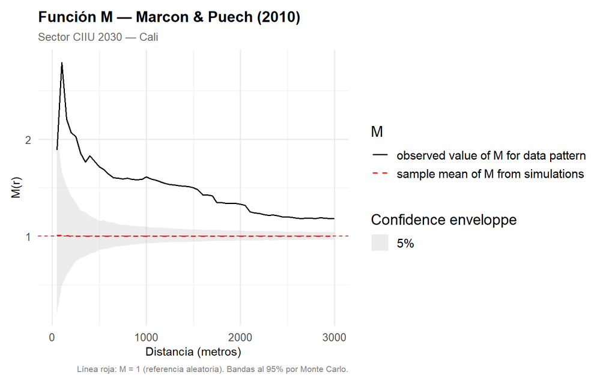

En consecuencia al analisis previo, el sector de fabricación de insumos intermedios para construcción en Cali exhibe aglomeración local de corto alcance en la zona central de la ciudad, impulsada por encadenamientos productivos y externalidades informacionales, Asimismo, posee una probabilidad mayor de encontrar dos pares de empresas en una menor distancia relativa a la economía general. Por otro lado, se encuentra que las decisiones de co-localización están incentivadas a barrios con una mayor participación economica del sector, sin embargo, no existe evidencia suficiente para una estructura de especialización sectorial propia en un barrio especifico diferente a la distribucion de especialización productiva dada en la ciudad de Cali.

## Referencias

Ellison, G., y Glaeser, E. L. (1997). Geographic concentration in U.S. manufacturing industries: A dartboard approach. *Journal of Political Economy*, *105*(5), 889–927. https://doi.org/10.1086/262098

Herfindahl, O. C. (1950). *Concentration in the steel industry* [Doctoral dissertation, Columbia University].

Hirschman, A. O. (1945). *National power and the structure of foreign trade*. University of California Press.

Marcon, E., y Puech, F. (2010). Measures of the geographic concentration of industries: Improving distance-based methods. *Journal of Economic Geography*, *10*(5), 745–762. https://doi.org/10.1093/jeg/lbp056

Maurel, F., y Sédillot, B. (1999). A measure of the geographic concentration in French manufacturing industries. *Regional Science and Urban Economics*, *29*(5), 575–604. https://doi.org/10.1016/S0166-0462(99)00020-4